# README

**REQUIRED** — A Stripe Account and API Key are required to use this module.

Follow the steps below to learn how to acquire an API Key and enter it into the Stripe Balance module.

## Steps to finish setup

- Log into the Stripe dashboard
- Locate your API Secret Key
- Enter your API Secret Key in Infinity Dashboard

## What is an API key and why do I need it?

> An application programming interface key (API key) is a code passed in by computer programs calling an application programming interface (API) to identify the calling program, its developer, or its user to the Web site.

An API Key will allow the Stripe Balance module access to your balance information without the need for a username and password.

## Logging into Stripe

- Click the following link to open the [Login Page](https://dashboard.stripe.com/account/apikeys)
- Follow the on screen steps to log into Stripe.
- You may be redirected to the API Keys page, but if you are not click the following link to open the [API Keys](https://dashboard.stripe.com/account/apikeys) page
- Continue to the next step to locate your API Secret Key.

## Locating your API Secret Key

Once you’ve loaded the API Keys page you will be brought to a page that looks like:

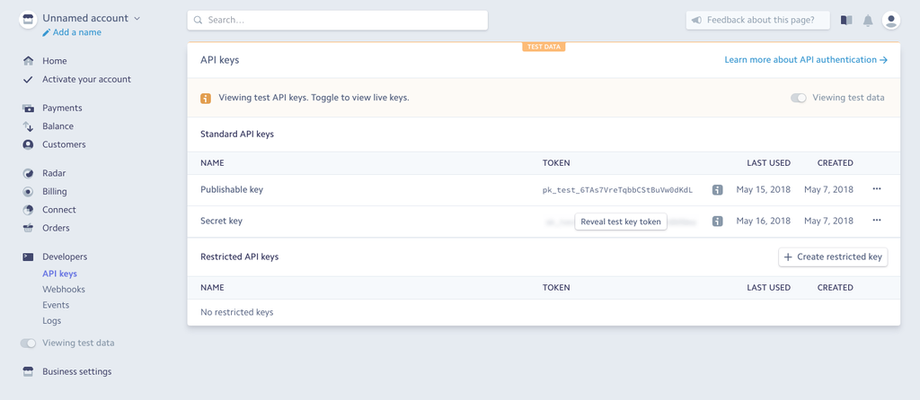

If you’re account is **Test Mode** make sure you first click the switch to toggle to the view the live keys.

- Locate the `Secret Key` section
- Click the `Reveal live key token` button in that section
  - **Note:** You may be asked to log in again, enter your login details to reveal the key.

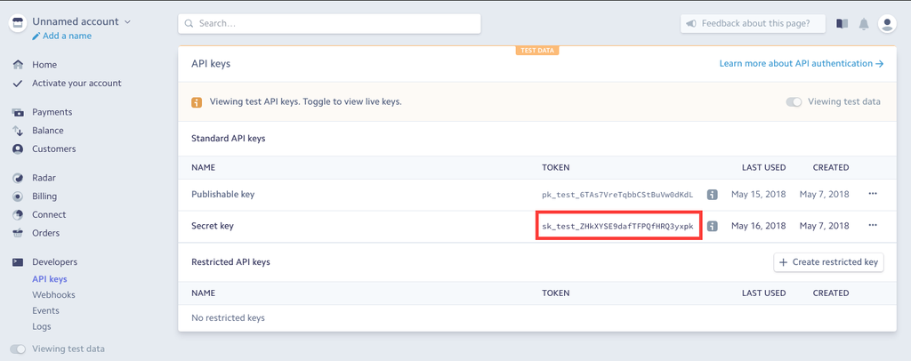

- Copy the revealed Secret Key by performing a `Right Click` and selecting the `Copy` action

## Entering your API Key into Infinity Dashboard

- Open Infinity Dashboard.app
- Click on the ‘Module Config’ item in the sidebar
- Locate the Stripe Balance module you want to configure
- Click the Pencil icon to open the module configuration
- Locate the **Stripe API Secret Key** config option
- Click the **The Secret Key for your Stripe Account.** label to edit this value.
- Paste the copied Secret Key into the field.

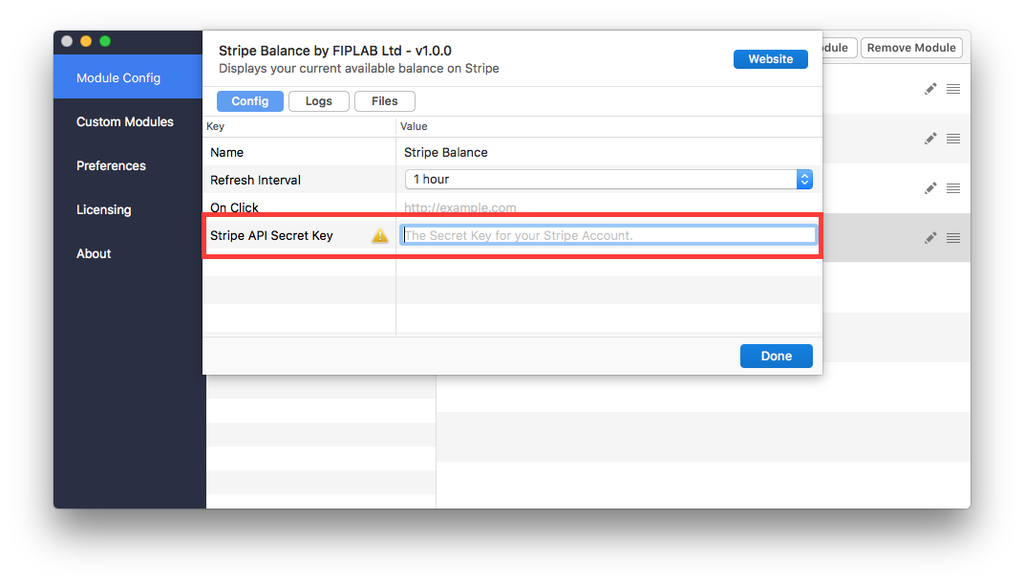

**Success** — You’re All Set!